# **Project: Twitter US Airline Sentiment - Ike Imala**

# **Data Description**:

- A sentiment analysis job about the problems of each major U.S. airline.
- Twitter data was scraped from February of 2015 and contributors were asked to first classify positive, negative, and neutral tweets, followed by categorizing negative reasons (such as "late flight" or "rude service").

# **Dataset**:

- The project is from a dataset from Kaggle.
- Link to the Kaggle project site:https://www.kaggle.com/crowdflower/twitter-airline-sentiment
- The dataset has to be downloaded from the above Kagglewebsite.

# **Objective**:

- To classify the sentiment of tweets into the positive, neutral & negative.

### Importing the necessary libraries

```python
!pip install nb_black
```

[output not shown]

```python
# Install and import necessary libraries.

!pip install contractions

import re, string, unicodedata                          # Import Regex, string and unicodedata.
import contractions                                     # Import contractions library.
from bs4 import BeautifulSoup                           # Import BeautifulSoup.

import numpy as np                                      # Import numpy.
import pandas as pd                                     # Import pandas.
import nltk                                             # Import Natural Language Tool-Kit.
import seaborn as sns                                   # Import seaborn
import matplotlib.pyplot as plt                         # Import Matplotlib

nltk.download('stopwords')                              # Download Stopwords.
nltk.download('punkt')
nltk.download('wordnet')

from nltk.corpus import stopwords                       # Import stopwords.
from nltk.tokenize import word_tokenize, sent_tokenize  # Import Tokenizer.
from nltk.stem.wordnet import WordNetLemmatizer         # Import Lemmatizer.
from wordcloud import WordCloud,STOPWORDS               # Import WorldCloud and Stopwords
from sklearn.feature_extraction.text import CountVectorizer # Import count Vectorizer
from sklearn.model_selection import train_test_split    # Import train test split
from sklearn.ensemble import RandomForestClassifier     # Import Rndom Forest Classifier
from sklearn.model_selection import cross_val_score     # Import cross val score
from sklearn.metrics import accuracy_score, classification_report
from sklearn.metrics import confusion_matrix            # Import confusion matrix
from wordcloud import WordCloud                         # Import Word Cloud
from sklearn.feature_extraction.text import TfidfVectorizer # Import Tf-Idf vector
import nltk
nltk.download('omw-1.4')
```

```
True
```

### Importing the necessary libraries

### Reading the dataset

```python
# Reading and loading the data into Pandas Dataframe
data = pd.read_csv("/content/Tweets.csv")
```

### Checking the shape of the dataset

```python
# Understanding the shape of the data
data.shape
```

```
(14640, 15)
```

- There are 14640 observations (row) and 15 features (column)

### Displaying the first few rows of the dataset

```python
# View the first 5 rows
data.head()
```

|  | tweet_id | airline_sentiment | airline_sentiment_confidence | negativereason | negativereason_confidence | airline | airline_sentiment_gold | name | negativereason_gold | retweet_count | text | tweet_coord | tweet_created | tweet_location | user_timezone |
| --- | --- | --- | --- | --- | --- | --- | --- | --- | --- | --- | --- | --- | --- | --- | --- |
| 0 | 570306133677760513 | neutral | 1.0000 | NaN | NaN | Virgin America | NaN | cairdin | NaN | 0 | @VirginAmerica What @dhepburn said. | NaN | 2015-02-24 11:35:52 -0800 | NaN | Eastern Time (US & Canada) |
| 1 | 570301130888122368 | positive | 0.3486 | NaN | 0.0000 | Virgin America | NaN | jnardino | NaN | 0 | @VirginAmerica plus you've added commercials to the experience... tacky. | NaN | 2015-02-24 11:15:59 -0800 | NaN | Pacific Time (US & Canada) |
| 2 | 570301083672813571 | neutral | 0.6837 | NaN | NaN | Virgin America | NaN | yvonnalynn | NaN | 0 | @VirginAmerica I didn't today... Must mean I need to take another trip! | NaN | 2015-02-24 11:15:48 -0800 | Lets Play | Central Time (US & Canada) |
| 3 | 570301031407624196 | negative | 1.0000 | Bad Flight | 0.7033 | Virgin America | NaN | jnardino | NaN | 0 | @VirginAmerica it's really aggressive to blast obnoxious "entertainment" in your guests' faces &amp; they have little recourse | NaN | 2015-02-24 11:15:36 -0800 | NaN | Pacific Time (US & Canada) |
| 4 | 570300817074462722 | negative | 1.0000 | Can't Tell | 1.0000 | Virgin America | NaN | jnardino | NaN | 0 | @VirginAmerica and it's a really big bad thing about it | NaN | 2015-02-24 11:14:45 -0800 | NaN | Pacific Time (US & Canada) |

- The target variable here is airline_sentiment value of **negative**, **positive** and **neutral** sentiments

```python
# Viewing the last 5 rows
data.tail()
```

|  | tweet_id | airline_sentiment | airline_sentiment_confidence | negativereason | negativereason_confidence | airline | airline_sentiment_gold | name | negativereason_gold | retweet_count | text | tweet_coord | tweet_created | tweet_location | user_timezone |
| --- | --- | --- | --- | --- | --- | --- | --- | --- | --- | --- | --- | --- | --- | --- | --- |
| 14635 | 569587686496825344 | positive | 0.3487 | NaN | 0.0000 | American | NaN | KristenReenders | NaN | 0 | @AmericanAir thank you we got on a different flight to Chicago. | NaN | 2015-02-22 12:01:01 -0800 | NaN | NaN |
| 14636 | 569587371693355008 | negative | 1.0000 | Customer Service Issue | 1.0000 | American | NaN | itsropes | NaN | 0 | @AmericanAir leaving over 20 minutes Late Flight. No warnings or communication until we were 15 minutes Late Flight. That's called shitty customer svc | NaN | 2015-02-22 11:59:46 -0800 | Texas | NaN |
| 14637 | 569587242672398336 | neutral | 1.0000 | NaN | NaN | American | NaN | sanyabun | NaN | 0 | @AmericanAir Please bring American Airlines to #BlackBerry10 | NaN | 2015-02-22 11:59:15 -0800 | Nigeria,lagos | NaN |
| 14638 | 569587188687634433 | negative | 1.0000 | Customer Service Issue | 0.6659 | American | NaN | SraJackson | NaN | 0 | @AmericanAir you have my money, you change my flight, and don't answer your phones! Any other suggestions so I can make my commitment?? | NaN | 2015-02-22 11:59:02 -0800 | New Jersey | Eastern Time (US & Canada) |
| 14639 | 569587140490866689 | neutral | 0.6771 | NaN | 0.0000 | American | NaN | daviddtwu | NaN | 0 | @AmericanAir we have 8 ppl so we need 2 know how many seats are on the next flight. Plz put us on standby for 4 people on the next flight? | NaN | 2015-02-22 11:58:51 -0800 | dallas, TX | NaN |

### Checking for missing values

```python
# checking for missing values
data.isnull().sum()
```

```
tweet_id                            0
airline_sentiment                   0
airline_sentiment_confidence        0
negativereason                   5462
negativereason_confidence        4118
airline                             0
airline_sentiment_gold          14600
name                                0
negativereason_gold             14608
retweet_count                       0
text                                0
tweet_coord                     13621
tweet_created                       0
tweet_location                   4733
user_timezone                    4820
dtype: int64
```

- There are a couple of missing values present in the data, however we will not be treating them as we only care about the text and airline_sentiment columns for modeling purpose which has no missing value

```python
# Check the data types of the columns for the dataset
data.info()
```

```
<class 'pandas.core.frame.DataFrame'>
RangeIndex: 14640 entries, 0 to 14639
Data columns (total 15 columns):
 #   Column                        Non-Null Count  Dtype
---  ------                        --------------  -----
 0   tweet_id                      14640 non-null  int64
 1   airline_sentiment             14640 non-null  object
 2   airline_sentiment_confidence  14640 non-null  float64
 3   negativereason                9178 non-null   object
 4   negativereason_confidence     10522 non-null  float64
 5   airline                       14640 non-null  object
 6   airline_sentiment_gold        40 non-null     object
 7   name                          14640 non-null  object
 8   negativereason_gold           32 non-null     object
 9   retweet_count                 14640 non-null  int64
 10  text                          14640 non-null  object
 11  tweet_coord                   1019 non-null   object
 12  tweet_created                 14640 non-null  object
 13  tweet_location                9907 non-null   object
 14  user_timezone                 9820 non-null   object
dtypes: float64(2), int64(2), object(11)
memory usage: 1.7+ MB
```

- The dataset has more object type column(string) than integer/float column

```python
# checking for duplicate values
data.duplicated().sum()
```

```
36
```

- There are 36 duplicates value present

### Removing dupplicates

```python
# dropping the duplicates
data = data.drop_duplicates(keep = 'first')

data.duplicated().sum()
```

```
0
```

```python
# resetting the index of the dataframe as dropping duplicates
data = data.reset_index(drop = True)
```

- The duplicate values have been removed

### Checking count for airline sentiment

```python
# Checking count for negative sentiment
data_negative_Sentiment= data[data['airline_sentiment'] == 'negative']

# Checking count for positive sentiment
data_positive_Sentiment= data[data['airline_sentiment'] == 'positive']

# checking count for neutral sentiment
data_neutral_Sentiment= data[data['airline_sentiment'] == 'neutral']
```

```python
print(f"Total number of negative tweets: {len(data_negative_Sentiment)}")

print(f"Total number of positive tweets: {len(data_positive_Sentiment)}")

print(f"Total number of neutral tweets: {len(data_neutral_Sentiment)}")
```

```
Total number of negative tweets: 9159
Total number of positive tweets: 2354
Total number of neutral tweets: 3091
```

- Majority of the sentiments are negative sentiments, with a total of 9159 compared to the rest. Hence the data appears to be imbalanced

### **Exploratory Data Analysis**

- EDA is an important part of any project involving data.
- It is important to investigate and understand the data better before building a model with it.

```python
# function to create labeled barplots


def labeled_barplot(data, feature, perc=False, n=None):
    """
    Barplot with percentage at the top

    data: dataframe
    feature: dataframe column
    perc: whether to display percentages instead of count (default is False)
    n: displays the top n category levels (default is None, i.e., display all levels)
    """

    total = len(data[feature])  # length of the column
    count = data[feature].nunique()
    if n is None:
        plt.figure(figsize=(count + 1, 5))
    else:
        plt.figure(figsize=(n + 1, 5))

    plt.xticks(rotation=90, fontsize=15)
    ax = sns.countplot(
        data=data,
        x=feature,
        palette="Paired",
        order=data[feature].value_counts().index[:n].sort_values(),
    )

    for p in ax.patches:
        if perc == True:
            label = "{:.1f}%".format(
                100 * p.get_height() / total
            )  # percentage of each class of the category
        else:
            label = p.get_height()  # count of each level of the category

        x = p.get_x() + p.get_width() / 2  # width of the plot
        y = p.get_height()  # height of the plot

        ax.annotate(
            label,
            (x, y),
            ha="center",
            va="center",
            size=12,
            xytext=(0, 5),
            textcoords="offset points",
        )  # annotate the percentage

    plt.show()  # show the plot
```

#### Percentage of tweets for each airline

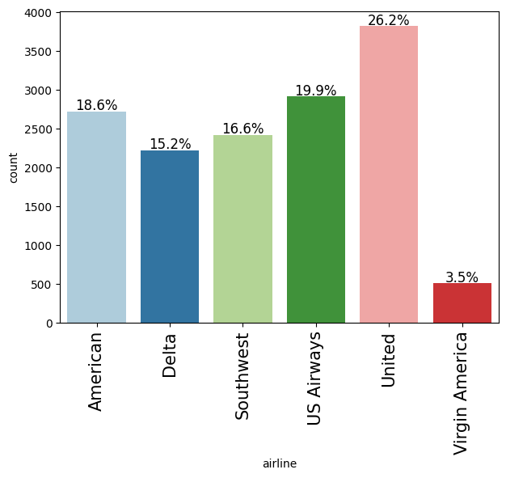

```python
# Plot the labeled barplot for airline
labeled_barplot(data, "airline", perc=True)
```

```python
# Count the occurrences of each unique airline tweets
airline_counts = data['airline'].value_counts()

# Calculate the total number of tweets
total_tweets = len(data)

# Calculate the percentage for each airline
percentage_tweets = (airline_counts / total_tweets) * 100

# Print the percentage for each airline
print(percentage_tweets)
```

```
United            26.170912
US Airways        19.946590
American          18.645577
Southwest         16.570803
Delta             15.215010
Virgin America     3.451109
Name: airline, dtype: float64
```

- United Airline has the highest number of tweets, next is US Airways followed by American Airline.

```python
print(airline_counts)
```

```
United            3822
US Airways        2913
American          2723
Southwest         2420
Delta             2222
Virgin America     504
Name: airline, dtype: int64
```

- United has 3822 total number of tweets, which confirms it has the highest percentage

### What is the distribution of sentiments across all the tweets?

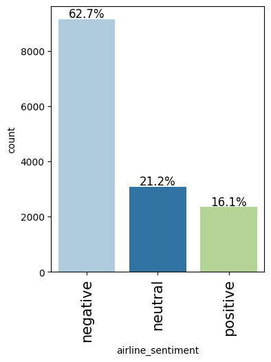

```python
# Check for distribution of airline_sentiment
labeled_barplot(data, "airline_sentiment", perc=True) # Complete the code to plot the labeled barplot for airline_sentiment
```

- Negative tweets are mostly common sentiments observed with 62%, 21.2% and 16.1% respectively for neutral and positive

#### What is the distribution of sentiments for each airline?

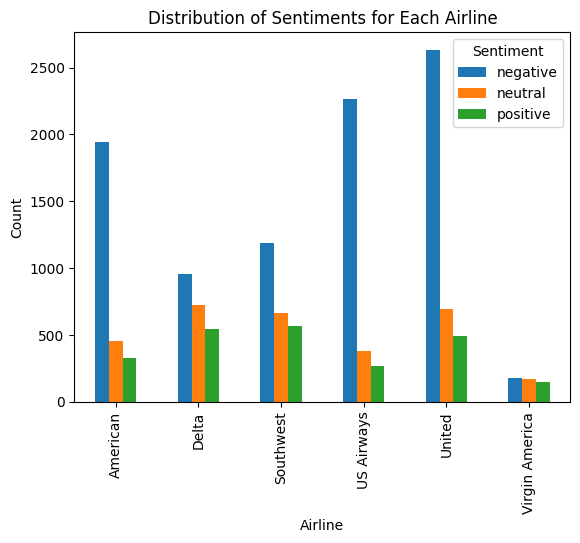

```python
# Plot the individual airline sentiment distribution for each airline
airline_sentiment = data.groupby(['airline', 'airline_sentiment']).airline_sentiment.count().unstack()

# Plot the barplot
airline_sentiment.plot(kind='bar')
plt.title('Distribution of Sentiments for Each Airline')
plt.xlabel('Airline')
plt.ylabel('Count')
plt.xticks(rotation=90)
plt.legend(title='Sentiment')
plt.show()
```

- Ngeative tweets are more common with most of the airlines, followed by neutral and then positive.
- It appears customers have negative sentiment about the airlines.
- United and US Airways are the two airlines with the most negative sentiment, which could also mean passengers fly united airline more
- Virgin has the least negative sentiment perhaps they have less customers flying the airline.

### Plot of all the negative reasons for all airline

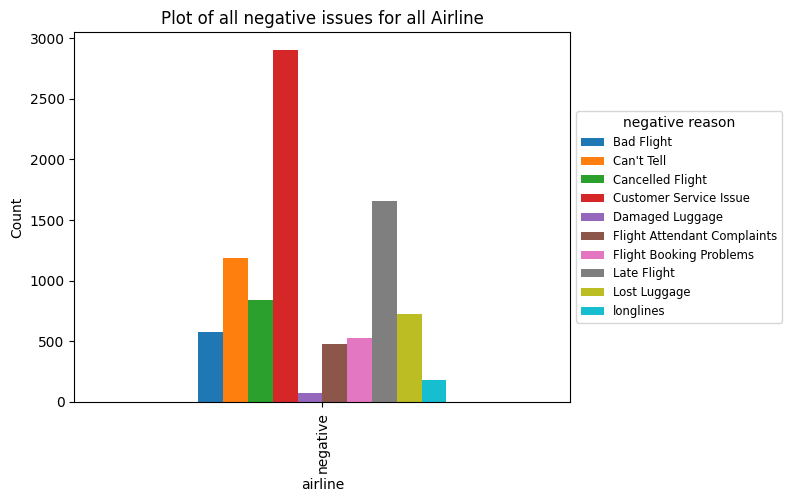

```python
# Plot the distribution of negative reason for all airline
negative_reason = data.groupby(['airline_sentiment', 'negativereason']).negativereason.count().unstack()

# Plot the barplot
negative_reason.plot(kind='bar')
plt.title('Plot of all negative issues for all Airline')
plt.xlabel('airline')
plt.ylabel('Count')
plt.xticks(rotation=90)
plt.legend(title='negative reason', fontsize='small', loc='center left', bbox_to_anchor=(1, 0.5))
plt.show()
```

- Customer service issue concerns was a major reason behind negative sentiment for all airlines, with late flight being the other major concern.
- Although some reasons were due to dammaged lauguage, however it was the least reason behind negative sentiments.

### Plot of all the negative reasons based on each airline

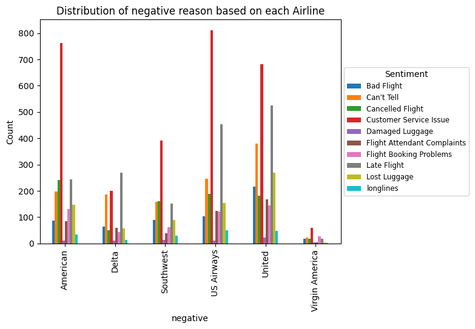

```python
negative_reason = data.groupby(['airline', 'negativereason']).negativereason.count().unstack()

# Plot the barplot
negative_reason.plot(kind='bar')
plt.title('Distribution of negative reason based on each Airline')
plt.xlabel('negative')
plt.ylabel('Count')
plt.xticks(rotation=90)
plt.legend(title='Sentiment', fontsize='small', loc='center left', bbox_to_anchor=(1, 0.5))
plt.show()
```

- United, US Airways and American are the three airlines has the higest no of negative concerns with most customer service issues.
- Delta Airline has the most concerns in late flight
- American Airline seems to have more canceled flight compared to the others.
- Virgin Atlantic has few complains, perhaps due to less customers.

```python
# Get all the negative data from the airline_sentiment column
airline_tweets=data[data['airline_sentiment']=='negative']
words = ' '.join(data['text'])
cleaned_word = " ".join([word for word in words.split()
                            if 'http' not in word
                                and not word.startswith('@')
                                and word != 'RT'])



print(cleaned_word)
```

```
What said. plus you've added commercials to the experience... tacky. I didn't today... Must mean I need to take another trip! it's really aggressive to blast obnoxious "entertainment" in your guests' faces &amp; they have little recourse and it's a really big bad thing about it seriously would pay $…
```

```python
 # Apply stopwords on cleaned words
wordcloud = WordCloud(stopwords=cleaned_word,
                      background_color='black',
                      width=3000,
                      height=2500
                     ).generate(words)
```

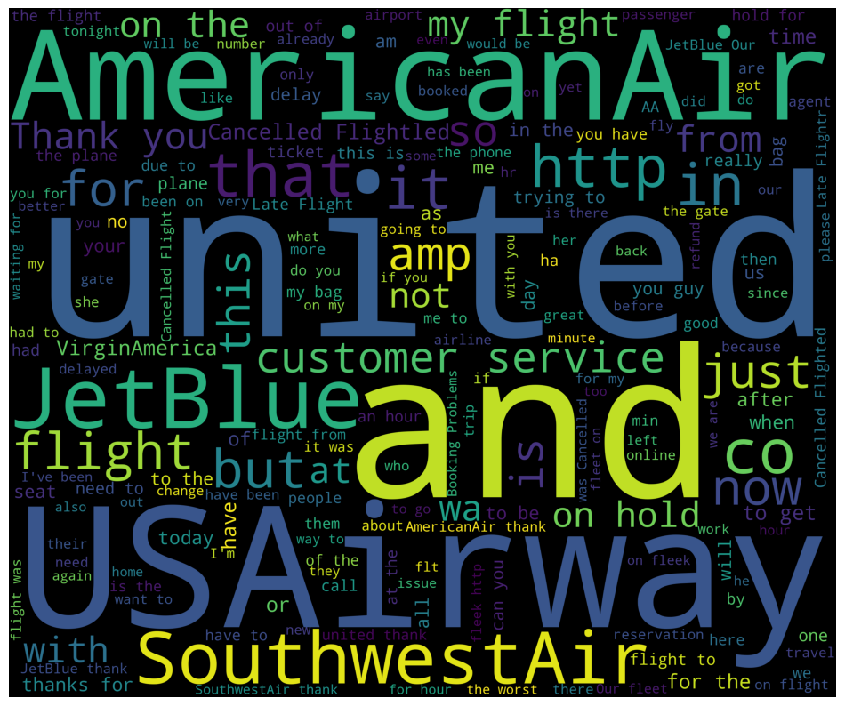

```python
 # Plot the wordcloud
plt.figure(1,figsize=(12, 12))
plt.imshow(wordcloud)
plt.axis('off')
plt.show()
```

```python
# Displaying the positive data from the airline_sentiment column
# Complete the code to join the text column from the data
airline_tweets=data[data['airline_sentiment']=='positive']
words = ' '.join(data['text'])
cleaned_word = " ".join([word for word in words.split()
                            if 'http' not in word
                                and not word.startswith('@')
                                and word != 'RT'
                            ])
```

```python
wordcloud = WordCloud(stopwords=cleaned_word,
                      background_color='black',
                      width=3000,
                      height=2500
                     ).generate(words)
```

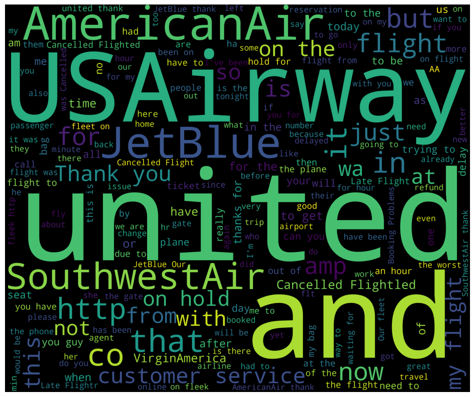

```python
 # Plot the wordcloud
plt.figure(1,figsize=(12, 12))
plt.imshow(wordcloud)
plt.axis('off')
plt.show()
```

### **Data Preparation for modeling**

- text and target column for sentiment analysis.

```python
# Extracting text and target column from the original dataframe into a new DataFrame for sentiment analysis.
df = data.loc[:, ['text', 'airline_sentiment']]
```

```python
# Run to display the entire dataframe information wihtout truncating the text information
pd.set_option('display.max_colwidth', None)
```

```python
# Display first 5 row of the new dataframe subset
df.head()
```

|  | text | airline_sentiment |
| --- | --- | --- |
| 0 | @VirginAmerica What @dhepburn said. | neutral |
| 1 | @VirginAmerica plus you've added commercials to the experience... tacky. | positive |
| 2 | @VirginAmerica I didn't today... Must mean I need to take another trip! | neutral |
| 3 | @VirginAmerica it's really aggressive to blast obnoxious "entertainment" in your guests' faces &amp; they have little recourse | negative |
| 4 | @VirginAmerica and it's a really big bad thing about it | negative |

```python
# Displaying unique values in airline sentiments column in dataframe
unique_values = df['airline_sentiment'].unique()

print(unique_values)
```

```
['neutral' 'positive' 'negative']
```

### Data Pre-processing:

Perform the below steps for data preprocessing.

- Remove html tags.
- Replace contractions in string. (e.g. replace I'm --> I am) and so on.\
- Remove numbers.
- Tokenization
- To remove Stopwords.
- Lemmatized data
- We have used NLTK library to tokenize words , remove stopwords and lemmatize the remaining words.

### Checking the text data to get a sense for the uncleaned data and what text preprocessing method is required prior to model building

```python
df['text'][6]
```

```
'@VirginAmerica yes, nearly every time I fly VX this “ear worm” won’t go away :)'
```

```python
df['text'][0]
```

```
'@VirginAmerica What @dhepburn said.'
```

```python
df['text'][4320]
```

```
'@united I tried 2 DM it would not go thru... not sure why'
```

```python
df['text'][1320]
```

```
'@united - Group 2 line gets longer every week. Almost no one left for Groups 3-5 anymore. Time to make Explorer Card Group 3?'
```

- Acronyms, stopwords, abbrevations, uppercase letters, punctuations marks, special characters like (@, ?) add to the noise in the unsctructured text and add no value to the meaning of the text, acronyms, out-of-vocabulary words, stopwords

```python
# Removing the html tags
def strip_html(text):
    soup = BeautifulSoup(text, "html.parser")
    return soup.get_text()

# Apply strip html function on text column
df['text'] = data['text'].apply(strip_html)
```

```python
# Let's look at the first 5 text messages
df['text'][0:5]
```

```
0                                                                                           @VirginAmerica What @dhepburn said.
1                                                      @VirginAmerica plus you've added commercials to the experience... tacky.
2                                                       @VirginAmerica I didn't today... Must mean I need to take another trip!
3    @VirginAmerica it's really aggressive to blast obnoxious "entertainment" in your guests' faces & they have little recourse
4                                                                       @VirginAmerica and it's a really big bad thing about it
Name: text, dtype: object
```

### Applying the contraction library and displaying new dataframe with text column to show contraction removed

```python
# Apply replace contractions function on text column
def replace_contractions(text):
    """Replace contractions in string of text"""
    return contractions.fix(text)

df['text'] = df['text'].apply(replace_contractions)
```

```python
data['text']
```

```
0                                                                                                                           @VirginAmerica What @dhepburn said.
1                                                                                      @VirginAmerica plus you've added commercials to the experience... tacky.
2                                                                                       @VirginAmerica I didn't today... Must mean I need to take another trip!
3                                @VirginAmerica it's really aggressive to blast obnoxious "entertainment" in your guests' faces &amp; they have little recourse
4                                                                                                       @VirginAmerica and it's a really big bad thing about it
                                                                                  ...
14599                                                                                           @AmericanAir thank you we got on a different flight to Chicago.
14600    @AmericanAir leaving over 20 minutes Late Flight. No warnings or communication until we were 15 minutes Late Flight. That's called shitty customer svc
14601                                                                                              @AmericanAir Please bring American Airlines to #BlackBerry10
14602                   @AmericanAir you have my money, you change my flight, and don't answer your phones! Any other suggestions so I can make my commitment??
14603                @AmericanAir we have 8 ppl so we need 2 know how many seats are on the next flight. Plz put us on standby for 4 people on the next flight?
Name: text, Length: 14604, dtype: object
```

```python
# Display first 5 rows of the data
df.head()
```

|  | text | airline_sentiment |
| --- | --- | --- |
| 0 | @VirginAmerica What @dhepburn said. | neutral |
| 1 | @VirginAmerica plus you have added commercials to the experience... tacky. | positive |
| 2 | @VirginAmerica I did not today... Must mean I need to take another trip! | neutral |
| 3 | @VirginAmerica it is really aggressive to blast obnoxious "entertainment" in your guests' faces & they have little recourse | negative |
| 4 | @VirginAmerica and it is a really big bad thing about it | negative |

- As observed removing the contraction word in the text column like, didn't , don't, it's, you've and expanding them to " it is, did not, do not, you have"

### Removing text with numbers and displaying text without numbers

```python
def remove_numbers(text):
    text = re.sub(r'\d+', '', text)  # Remove numbers using regular expression substitution
    return text

# Apply remove_numbers to the 'text' column
df['text'] = df['text'].apply(remove_numbers)
```

```python
# Display text in dataframe without number
df['text'].head(10)
```

```
0                                                                                                         @VirginAmerica What @dhepburn said.
1                                                                  @VirginAmerica plus you have added commercials to the experience... tacky.
2                                                                    @VirginAmerica I did not today... Must mean I need to take another trip!
3                 @VirginAmerica it is really aggressive to blast obnoxious "entertainment" in your guests' faces & they have little recourse
4                                                                                    @VirginAmerica and it is a really big bad thing about it
5    @VirginAmerica seriously would pay $ a flight for seats that did not have this playing.\nit is really the only bad thing about flying VA
6                                                          @VirginAmerica yes, nearly every time I fly VX this “ear worm” will not go away :)
7                                 @VirginAmerica Really missed a prime opportunity for Men Without Hats parody, there. https://t.co/mWpGgrEZP
8                                                                                            @virginamerica Well, I did not…but NOW I DO! :-D
9                                                           @VirginAmerica it was amazing, and arrived an hour early. You are too good to me.
Name: text, dtype: object
```

- As observed the numbers have been removed from the text column

### Applying tokenization to text column

```python
# Function for tokenization
def tokenize_text(text):
    tokens = nltk.word_tokenize(text)
    return tokens
```

```python
# Apply tokenization to the 'text' column
df['text'] = df.apply(lambda row: tokenize_text(row['text']), axis=1)
```

```python
df['text'].head(10)
```

```
0                                                                                                                           [@, VirginAmerica, What, @, dhepburn, said, .]
1                                                                              [@, VirginAmerica, plus, you, have, added, commercials, to, the, experience, ..., tacky, .]
2                                                                             [@, VirginAmerica, I, did, not, today, ..., Must, mean, I, need, to, take, another, trip, !]
3                 [@, VirginAmerica, it, is, really, aggressive, to, blast, obnoxious, ``, entertainment, '', in, your, guests, ', faces, &, they, have, little, recourse]
4                                                                                                   [@, VirginAmerica, and, it, is, a, really, big, bad, thing, about, it]
5    [@, VirginAmerica, seriously, would, pay, $, a, flight, for, seats, that, did, not, have, this, playing, ., it, is, really, the, only, bad, thing, about, flying, VA]
6                                                            [@, VirginAmerica, yes, ,, nearly, every, time, I, fly, VX, this, “, ear, worm, ”, will, not, go, away, :, )]
7                                      [@, VirginAmerica, Really, missed, a, prime, opportunity, for, Men, Without, Hats, parody, ,, there, ., https, :, //t.co/mWpGgrEZP]
8                                                                                                       [@, virginamerica, Well, ,, I, did, not…but, NOW, I, DO, !, :, -D]
9                                                                [@, VirginAmerica, it, was, amazing, ,, and, arrived, an, hour, early, ., You, are, too, good, to, me, .]
Name: text, dtype: object
```

```python
len('text')
```

```
4
```

#### Apply Stopwords

```python
# Define default set of stopwords from the NLTK library using stopwords.words('english')
stopwords = stopwords.words('english')

# Define a custom list of words (customlist) that needs to be excluded from the stopwords list
customlist = ['not', "couldn't", 'didn', "didn't", 'doesn', "doesn't", 'hadn', "hadn't", 'hasn',
        "hasn't", 'haven', "haven't", 'isn', "isn't", 'ma', 'mightn', "mightn't", 'mustn',
        "mustn't", 'needn', "needn't", 'shan', "shan't", 'shouldn', "shouldn't", 'wasn',
        "wasn't", 'weren', "weren't", 'won', "won't", 'wouldn', "wouldn't"]

# Removing the customlist from the stopwords list
# Subtracting the words in customlist from the original stopwords, so we don't remove the words in the custom list in the Text
stopwords = list(set(stopwords) - set(customlist))
```

```python
lemmatizer = WordNetLemmatizer()

def remove_non_ascii(words):
    """Remove non-ASCII characters from list of tokenized words"""
    new_words = []
    for word in words:
        new_word = unicodedata.normalize('NFKD', word).encode('ascii', 'ignore').decode('utf-8', 'ignore')
        new_words.append(new_word)
    return new_words

def to_lowercase(words):
    """Convert all characters to lowercase from list of tokenized words"""
    new_words = []
    for word in words:
        new_word = word.lower()
        new_words.append(new_word)
    return new_words

def remove_punctuation(words):
    """Remove punctuation from list of tokenized words"""
    new_words = []
    for word in words:
        new_word = re.sub(r'[^\w\s]', '', word)
        if new_word != '':
            new_words.append(new_word)
    return new_words

def remove_stopwords(words):
    """Remove stop words from list of tokenized words"""
    new_words = []
    for word in words:
        if word not in stopwords:
            new_words.append(word)
    return new_words

def lemmatize_list(words):
    new_words = []
    for word in words:
      new_words.append(lemmatizer.lemmatize(word, pos='v'))
    return new_words

def normalize(words):
    words = remove_non_ascii(words)
    words = to_lowercase(words)
    words = remove_punctuation(words)
    words = remove_stopwords(words)
    words = lemmatize_list(words)
    return ' '.join(words)

df['text'] = df.apply(lambda row: normalize(row['text']), axis=1)
df.head()
```

|  | text | airline_sentiment |
| --- | --- | --- |
| 0 | virginamerica dhepburn say | neutral |
| 1 | virginamerica plus add commercials experience tacky | positive |
| 2 | virginamerica not today must mean need take another trip | neutral |
| 3 | virginamerica really aggressive blast obnoxious entertainment guests face little recourse | negative |
| 4 | virginamerica really big bad thing | negative |

- As we can observe after performing a sequence of text preprocessing technique on the data we have a completely clean data prior to model building.
- We will first perform vectorization on the cleaned data prior to the model building stage

### Build the model based on countvectorizer and Random forest

## **Bag of Words (CountVectorizer)**

A bag of words is a representation of text that describes the occurrence of words within a document.

### Intializing countvectorizer and use it for vectorization

```python
# Vectorization (Converting text data to numbers).

# Initailize CounterVectorizer function with max_features 5000
Count_vec = CountVectorizer(max_features = 5000)

# fit and transform the count_vec variable on the text column
df_features = Count_vec.fit_transform(df['text'])


# Convert the df features to array
df_features = df_features.toarray()
```

```python
# Shape of the feature vector
df_features.shape
```

```
(14604, 5000)
```

#### Store Independent and Dependent variables

```python
# Independent Variable stored as X
X = df_features

# Dependent Variable stored as Y
y = df.airline_sentiment
```

#### Split the data into train and test

```python
# Split the X and Y into train and test data with 75% training and 25% test data
X_train, X_test, y_train, y_test = train_test_split(X, y, test_size = 0.25, random_state= 1)
```

#### Building Random Forest Model

```python
# Using Random Forest to build model for the classification of sentiments.

clf = RandomForestClassifier(n_estimators = 100, n_jobs=4)

clf = clf.fit(X_train, y_train)

print(clf)

print(np.mean(cross_val_score(clf, X, y, cv=10)))
```

```
RandomForestClassifier(n_jobs=4)
0.7356166727611976
```

- Using n_estimators of 100(number of trees/classifier) on the training data we obtained an average score perfomance metric of 73%. Which is not very impressive.
- Hence, we can tune the n_estimators parameter using techniques like cross-validation to find the optimal value for our data to be used.

#### Optimize the parameter: The number of trees in the random forest model(n_estimators)

```python
# Finding optimal number of base learners using k-fold CV ->
base_ln = [x for x in range(1, 25)]
```

```python
# Initializing an empty list to store the scores
cv_scores = []

for b in base_ln:
    clf = RandomForestClassifier(n_estimators=b) # Apply Random Forest Classifier
    scores = cross_val_score(clf, X, y, cv=5, scoring='accuracy')  # Perform cross-validation score on the classifier (clf) for accuracy
    cv_scores.append(scores.mean())  # Append the mean score to cv_scores list

print(cv_scores)
```

```
[0.621819089915726, 0.6585857254740121, 0.6620099609347522, 0.6753616466494399, 0.6917273358251302, 0.6952191733924862, 0.7076143232989265, 0.6931649416366136, 0.7061056684471916, 0.7002872913667209, 0.693849568312597, 0.7067901544320063, 0.7042590030623778, 0.7069280552259736, 0.7052150699000623, 0…
```

- Above, a loop is done to perform cross-validation with different values of n_estimators for a Random Forest Classifier and stores the mean accuracy scores in the cv_scores list.
- The cv_scores shows the mean accuracy scores for each value of n_estimators.
- We can conclude that the performance of the Random Forest Classifier changes with different numbers of trees (n_estimators), with an maximum percentage score of 71%. Hence, even with cross-validation optimal parameter search we are not able to obtain a higher CV metric score.

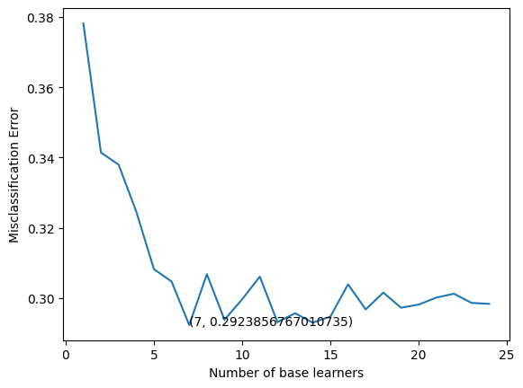

```python
# plot the error as k increases
error = [1 - x for x in cv_scores]                                 # Error corresponds to each number of estimator
optimal_learners = base_ln[error.index(min(error))]                # Choosing the optimal number of n_estimator corresponds to minimum error.
plt.plot(base_ln, error)                                           # Plot between each number of estimator and misclassification error
xy = (optimal_learners, min(error))
plt.annotate('(%s, %s)' % xy, xy = xy, textcoords='data')
plt.xlabel("Number of base learners")
plt.ylabel("Misclassification Error")
plt.show()
```

```python
# Initialize the Random Forest classifier with optimal learners
clf = RandomForestClassifier(n_estimators=optimal_learners)

# Fit the classifier on the training data
clf.fit(X_train, y_train)

# Find the accuracy score on the training data
train_accuracy = clf.score(X_train, y_train)
print("Training Accuracy:", train_accuracy)

# Find the accuracy score on the test data
test_accuracy = clf.score(X_test, y_test)
print("Test Accuracy:", test_accuracy)
```

```
Training Accuracy: 0.9720624486442071
Test Accuracy: 0.7274719254998631
```

- Using the n_estimators and best learners our model performs better on the training data but fair on the test data. It appears we have a bit of overfitting in the model.

```python
# Predict the result for test data using the model classifier above.
result = clf.predict(X_test)
```

```python
# Function to print the classification report and get confusion matrix in a proper format

def metrics_score(actual, predicted):

    print(classification_report(actual, predicted))

    cm = confusion_matrix(actual, predicted)

    plt.figure(figsize = (8, 5))

    sns.heatmap(cm, annot = True,  fmt = '.2f', xticklabels = ['negative', 'positive', 'neutral'], yticklabels = ['negative', 'positive', 'neutral'])

    plt.ylabel('Actual')

    plt.xlabel('Predicted')

    plt.show()
```

```
              precision    recall  f1-score   support

    negative       0.80      0.88      0.84      2296
     neutral       0.50      0.46      0.48       775
    positive       0.65      0.50      0.57       580

    accuracy                           0.73      3651
   macro avg       0.65      0.61      0.63      3651
weighted avg       0.72      0.73      0.72      3651
```

[figure not shown]

```python
metrics_score(y_test, result)
```

- The airline_sentiment on the negative tweets have a much higher prediction metrics compared to the rest of the sentiments

```python
all_features = Count_vec.get_feature_names_out()
top_features=''                                                  # Addition of top 40 feature into top_feature after training the model
feat=clf.feature_importances_
features=np.argsort(feat)[::-1]
for i in features[0:40]:
    top_features+=all_features[i]
    top_features+=','

print(top_features)

print(" ")
print(" ")

# Complete the code by applying wordcloud on top features
wordcloud = WordCloud(background_color="white",colormap='viridis',width=2000,height=1000).generate(top_features)
```

```
thank,not,jetblue,delay,http,usairways,flight,great,southwestair,love,awesome,hold,unite,americanair,get,cancel,best,bag,virginamerica,call,tell,service,hours,please,time,dm,fleek,amaze,appreciate,still,go,help,plane,follow,fly,good,hour,sit,never,customer,
```

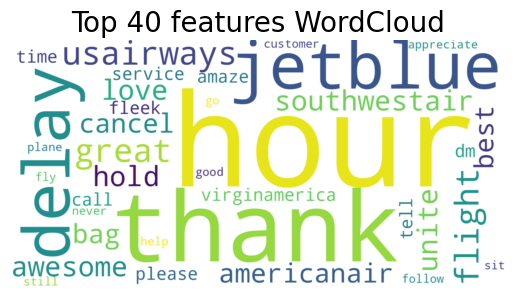

```python
# Displaying the generated top 40 WordCloud image:
plt.imshow(wordcloud, interpolation='bilinear')
plt.figure(1, figsize=(14, 11), frameon='equal')
plt.title('Top 40 features WordCloud', fontsize=20)
plt.axis("off")
plt.show()
```

- US Airways, JetBlue, hour, thank, delay, awesome, please are some of the most frequent word in the text data.

#### Using TfidfVectorizer to convert text data to numbers.

```python
# initialize the TF-IDF vector function with max_features = 5000

tfidf_vect = TfidfVectorizer(max_features = 5000)

# Fit the tf idf function on the text column
df_features = tfidf_vect.fit_transform(data['text'])

# convert the datafram into array
df_features = df_features.toarray()
```

```python
# checking shape
df_features.shape
```

```
(14604, 5000)
```

#### Store Independent and Dependent feature in X and Y variable

```python
X = df_features

y = df.airline_sentiment
```

#### Split the data into train and test

```python
# Complete the code to split the X and Y into train and test data
X_train, X_test, y_train, y_test = train_test_split(X, y, test_size = 0.25, random_state= 1)
```

#### Using Random Forest to build model for the classification of airline sentiment

```python
# Initialize the Random Forest Classifier

clf_2 = RandomForestClassifier(n_estimators = 100, n_jobs=4)            # Initialize the Random Forest Classifier

# Fit the forest variable on X_train and y_train
clf_2 = clf.fit(X_train, y_train)

print(clf_2)

# Calculate cross validation score
print(np.mean(cross_val_score(clf_2, X, y, cv=10)))
```

```
RandomForestClassifier(n_estimators=7)
0.6944632593551049
```

```python
# Finding optimal number of base learners using k-fold CV ->
base_ln = [x for x in range(1, 25)]
```

```python
# K-Fold Cross - validation .
cv_scores = []  # Initializing an empty list to store the scores

for b in base_ln:
    clf_2 = RandomForestClassifier(n_estimators=b)  # Apply Random Forest Classifier
    scores = cross_val_score(clf, X, y, cv=5, scoring='accuracy')  # Perform cross-validation score on the classifier (clf) for accuracy
    cv_scores.append(scores.mean())  # Append the mean score to cv_scores list

print(cv_scores)
```

```
[0.6917969076081094, 0.6989862966801573, 0.699055258801405, 0.6789247442938007, 0.6860461326342545, 0.686045851251917, 0.6902209554806245, 0.683990892591672, 0.7004929115099445, 0.6913178776268214, 0.6867985724536071, 0.692206834776981, 0.6884424315185736, 0.7042591672020746, 0.6916606013140555, 0.6…
```

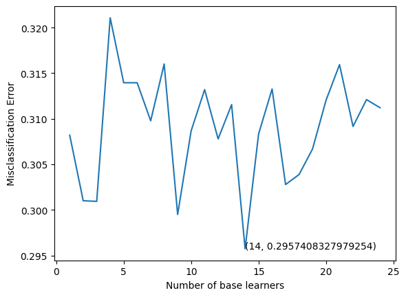

```python
# plot the error as k-fold increases
error = [1 - x for x in cv_scores]                                 # Error corresponds to each number of estimator
optimal_learners = base_ln[error.index(min(error))]                # Selection of optimal number of n_estimator corresponds to minimum error.
plt.plot(base_ln, error)                                           # Plot between each number of estimator and misclassification error
xy = (optimal_learners, min(error))
plt.annotate('(%s, %s)' % xy, xy = xy, textcoords='data')
plt.xlabel("Number of base learners")
plt.ylabel("Misclassification Error")
plt.show()
```

```python
# Initialize the Random Forest classifier with optimal learners
clf_2 = RandomForestClassifier(n_estimators=optimal_learners)

# Fit the classifier on the training data
clf_2.fit(X_train, y_train)

# Find the accuracy score on the training data
train_accuracy = clf_2.score(X_train, y_train)
print("Training Accuracy:", train_accuracy)

# Find the accuracy score on the test data
test_accuracy = clf.score(X_test, y_test)
print("Test Accuracy:", test_accuracy)
```

```
Training Accuracy: 0.9725189445813932
Test Accuracy: 0.7288414133114215
```

- Using the n_estimators and best learners our model performs better on the training data. The model is not generalizable, as the performs is lower on the test data.

```python
# Predict the result for test data using the model classifier above.
result2 = clf_2.predict(X_test)
```

```python
# Function to print the classification report and get confusion matrix in a proper format

def metrics_score(actual, predicted):

    print(classification_report(actual, predicted))

    cm = confusion_matrix(actual, predicted)

    plt.figure(figsize = (8, 5))

    sns.heatmap(cm, annot = True,  fmt = '.2f', xticklabels = ['negative', 'positive', 'neutral'], yticklabels = ['negative', 'positive', 'neutral'])

    plt.ylabel('Actual')

    plt.xlabel('Predicted')

    plt.show()
```

```
              precision    recall  f1-score   support

    negative       0.75      0.93      0.83      2296
     neutral       0.59      0.37      0.45       775
    positive       0.73      0.38      0.50       580

    accuracy                           0.73      3651
   macro avg       0.69      0.56      0.59      3651
weighted avg       0.71      0.73      0.70      3651
```

[figure not shown]

```python
metrics_score(y_test, result2)
```

- The airline_sentiment on the negative tweets have a much higher prediction metrics compared to the rest of the sentiments.
- Recall and F1 score appears very good for negative sentiments.

```python
all_features = tfidf_vect.get_feature_names_out()
top_features=''
feat=clf_2.feature_importances_
features=np.argsort(feat)[::-1]
for i in features[0:40]:
    top_features+=all_features[i]
    top_features+=', '

print(top_features)

print(" ")
print(" ")


# Complete the code by applying wordcloud on top features
wordcloud = WordCloud(background_color="white",colormap='viridis',width=2000,height=1000).generate(top_features)
```

```
thanks, thank, jetblue, southwestair, you, not, great, united, to, and, the, americanair, for, usairways, on, co, is, your, love, virginamerica, http, can, been, it, no, flight, my, hold, our, hours, cancelled, in, that, was, but, be, awesome, dm, have, of,
```

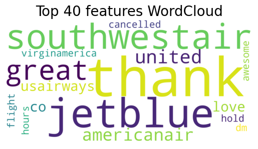

```python
# Display the generated image:
plt.imshow(wordcloud, interpolation='bilinear')
plt.figure(1, figsize=(14, 11), frameon='equal')
plt.title('Top 40 features WordCloud', fontsize=20)
plt.axis("off")
plt.show()
```

```python
#convert the test samples into a dataframe where the columns are

#the y_test(ground truth labels),tf-idf model predicted labels(tf_idf_predicted),
#Count Vectorizer model predicted labels(count_vectorizer_predicted)

df = pd.DataFrame(y_test.tolist(), columns = ['y_test'])

df['count_vectorizer_predicted'] = result

df['tf_idf_predicted'] = result2

df.head(10)
```

|  | y_test | count_vectorizer_predicted | tf_idf_predicted |
| --- | --- | --- | --- |
| 0 | neutral | neutral | neutral |
| 1 | positive | positive | positive |
| 2 | negative | negative | negative |
| 3 | negative | negative | negative |
| 4 | negative | negative | negative |
| 5 | positive | negative | negative |
| 6 | positive | positive | positive |
| 7 | neutral | positive | positive |
| 8 | positive | positive | positive |
| 9 | negative | negative | negative |

```python
df.head()
```

|  | y_test | count_vectorizer_predicted | tf_idf_predicted |
| --- | --- | --- | --- |
| 0 | neutral | neutral | neutral |
| 1 | positive | positive | positive |
| 2 | negative | negative | negative |
| 3 | negative | negative | negative |
| 4 | negative | negative | negative |

## **Sequential model - LSTM**

#### Using Neural Network for Sentiment Analysis

```python
# Used to create the Sequential model
from keras.models import Sequential
import tensorflow
# Used to create the tokens from the text data
from tensorflow.keras.preprocessing.text import Tokenizer

# Helps to pad the sequences into the same length
from tensorflow.keras.preprocessing.sequence import pad_sequences

# Layers that are used to implement the LSTM model
from tensorflow.keras.layers import Dense, Embedding, LSTM, SpatialDropout1D
```

**Components of the LSTM**

The LSTM cell contains the following components:

- Forget Gate “f” ( a neural network with sigmoid)
- Candidate layer “C"(a NN with Tanh)
- Input Gate “I” ( a NN with sigmoid )
- Output Gate “O”( a NN with sigmoid)
- Hidden state “H” ( a vector )
- Memory state “C” ( a vector)

Inputs to the LSTM cell at any step are Xt (current input) , Ht-1 (previous hidden state ) and Ct-1 (previous memory state).

Outputs from the LSTM cell are Ht (current hidden state ) and Ct (current memory state)

**Working of gates in LSTM**

First, LSTM cell takes the previous memory state Ct-1 and does element wise multiplication with forget gate (f) to decide if present memory state Ct. If forget gate value is 0 then previous memory state is completely forgotten else f forget gate value is 1 then previous memory state is completely passed to the cell ( Remember f gate gives values between 0 and 1 ).

Ct = Ct-1 * ft

Calculating the new memory state:

Ct = Ct + (It * C`t)

Now, we calculate the output:

Ht = tanh(Ct)

### **Tokenizing and converting the text into numerical vectors**

```python
# Creating the tokenizer with 700 vocab size
tokenizer = Tokenizer(num_words = 1000, split = ' ')

tokenizer.fit_on_texts(df['text'].values)

# converting text to sequences
X = tokenizer.texts_to_sequences(df['text'].values)

# Padding the sequences
X = pad_sequences(X)
```

```python
model = Sequential()

# Model will take as input an integer matrix of size (batch, input_length), and the largest integer (i.e. word index) in the input
# input_length is X_data[1] = 1000 here.
model.add(Embedding(1000, 120, input_length = X.shape[1]))

model.add(SpatialDropout1D(0.2))

 # return_sequences = True means each LSTM cell in it is outputting its value.The output of the layer is a sequence of outputs.
model.add(LSTM(150, dropout = 0.2, recurrent_dropout = 0.2))

model.add(Dense(3, activation = 'softmax'))

# compile the model
model.compile(loss = 'categorical_crossentropy', optimizer = 'adam', metrics = ['accuracy'])
```

```python
print(model.summary())
```

```
Model: "sequential"
_________________________________________________________________
 Layer (type)                Output Shape              Param #
=================================================================
 embedding (Embedding)       (None, 21, 120)           120000

 spatial_dropout1d (SpatialD  (None, 21, 120)          0
 ropout1D)

 lstm (LSTM)                 (None, 150)               162600

 dense (Dense)               (None, 3)                 453

=================================================================
Total params: 283,053
Trainable params: 283,053
Non-trainable params: 0
_________________________________________________________________
None
```

A sequential model is constructed by adding various layers to it.

- The first layer is the Embedding layer which transforms one-hot encoded sparse vectors into Word Embedding vectors. As the model continues to train, the weights of the Embedding layer are adjusted so that words with similar meanings are located closer together in the vector space, or have similar Word Embedding Vectors. For example, "orange" would be located near "tangerine" and "queen" would be near "empress." The vocabulary size is specified.
- The subsequent layer is an LSTM layer with 150 neurons. The input for this layer is a list of sentences, where each word has been converted to its corresponding Embedding vector and padded to have the same length. To prevent bias, a dropout layer is employed to regulate the network.
- The final layer is a Dense layer which serves as the output layer and has 3 cells to perform classification, representing the 3 different categories in this dataset.
- The model is then compiled using the Adam optimizer and categorical cross-entropy. The Adam optimizer is currently the best choice for handling sparse gradients and noisy problems, and categorical cross-entropy is typically used when the classes are mutually exclusive, meaning each sample belongs to exactly one class.

#### **Splitting the Data**

```python
# creating the target feature
y = pd.get_dummies(data['airline_sentiment'])
```

```python
print(X_train.shape)
print(y_train.shape)
```

```
(10953, 5000)
(10953,)
```

```python
# Splitting the data into training and testing
X_train, X_test, y_train, y_test = train_test_split(X, y, test_size = 0.2, random_state = 42, stratify=y)
```

```python
print(X_train.shape)
print(y_train.shape)
```

```
(11683, 21)
(11683, 3)
```

```python
print(X_test.shape)
print(y_test.shape)
```

```
(2921, 21)
(2921, 3)
```

#### **Training the model**

```python
# specifying the batch size
batch_size = 32

# fitting the model on the training data with 10 epochs
LSTM_model1 = model.fit(X_train, y_train, epochs = 10, batch_size = batch_size, verbose = 'auto')
```

#### **Plotting the model**

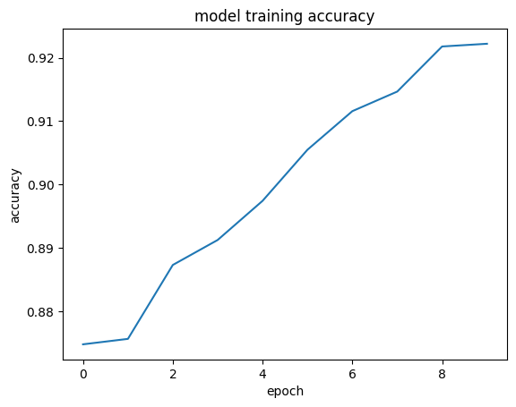

```python
# accessing the accuracy from the his variable
plt.plot(LSTM_model1.history['accuracy'])
# setting the title
plt.title('model training accuracy')
plt.ylabel('accuracy')
plt.xlabel('epoch')
plt.show()
```

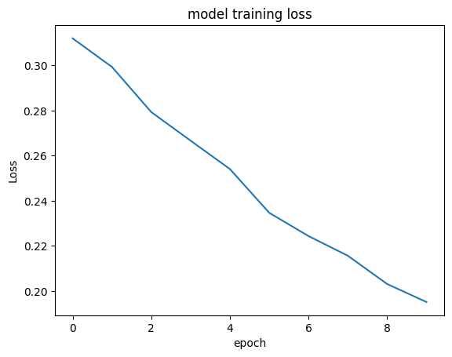

```python
# accessing the loss from the his variable
plt.plot(LSTM_model1.history['loss'])
# setting the title
plt.title('model training loss')
plt.ylabel('Loss')
plt.xlabel('epoch')
plt.show()
```

#### **Evaluating the model on the test data**

```python
model.evaluate(X_test,y_test)
```

```
[1.0501892566680908, 0.752481997013092]
```

```python
ypred = model.predict(X_test)
```

```python
ypred
```

```
array([[8.4495890e-01, 1.5483220e-01, 2.0893934e-04],
       [9.9940431e-01, 5.1052775e-04, 8.5220818e-05],
       [9.9804968e-01, 3.8693099e-07, 1.9499552e-03],
       ...,
       [1.1807051e-03, 9.9827766e-01, 5.4153422e-04],
       [9.9600750e-01, 3.9923191e-03, 1.6362240e-07],
       [9.9952614e-01, 2.8170296e-05, 4.4580491e-04]], dtype=float32)
```

The model is giving around 75% accuracy on the test data

### LSTM - Model 2 - The subsequent layer is an LSTM layer with 100 neurons

```python
model2 = Sequential()

# Model will take as input an integer matrix of size (batch, input_length), and the largest integer (i.e. word index) in the input
# input_length is X_data[1] = 1000 here.
model2.add(Embedding(1000, 120, input_length = X.shape[1]))

model2.add(SpatialDropout1D(0.2))

 # return_sequences = True means each LSTM cell in it is outputting its value.The output of the layer is a sequence of outputs.
model2.add(LSTM(100, dropout = 0.2, recurrent_dropout = 0.2))


model2.add(Dense(3, activation = 'softmax'))

# compile the model
model2.compile(loss = 'categorical_crossentropy', optimizer = 'adam', metrics = ['accuracy'])
```

```python
print(model2.summary())
```

```
Model: "sequential_4"
_________________________________________________________________
 Layer (type)                Output Shape              Param #
=================================================================
 embedding_4 (Embedding)     (None, 21, 120)           120000

 spatial_dropout1d_3 (Spatia  (None, 21, 120)          0
 lDropout1D)

 lstm_4 (LSTM)               (None, 100)               88400

 dense_2 (Dense)             (None, 3)                 303

=================================================================
Total params: 208,703
Trainable params: 208,703
Non-trainable params: 0
_________________________________________________________________
None
```

```python
# specifying the batch size
batch_size = 32

# fitting the model on the training data with 10 epochs
LSTM_model2 = model2.fit(X_train, y_train, epochs = 10, batch_size = batch_size, verbose = 'auto')
```

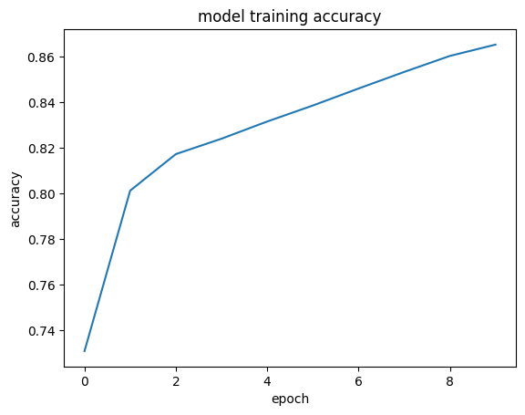

```python
# accessing the accuracy from the his variable
plt.plot(LSTM_model2.history['accuracy'])
# setting the title
plt.title('model training accuracy')
plt.ylabel('accuracy')
plt.xlabel('epoch')
plt.show()
```

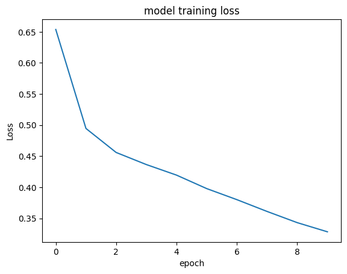

```python
# accessing the loss from the his variable
plt.plot(LSTM_model2.history['loss'])
# setting the title
plt.title('model training loss')
plt.ylabel('Loss')
plt.xlabel('epoch')
plt.show()
```

```python
model2.evaluate(X_test,y_test)
```

```
[0.6331729292869568, 0.7802122831344604]
```

```python
ypred2 = model2.predict(X_test)
```

```python
ypred2
```

```
array([[8.5709101e-01, 1.2107430e-01, 2.1834703e-02],
       [6.6172493e-01, 3.2530552e-01, 1.2969499e-02],
       [1.8170357e-01, 6.5192739e-03, 8.1177717e-01],
       ...,
       [6.1817255e-02, 9.0071648e-01, 3.7466269e-02],
       [6.5063608e-01, 3.4933725e-01, 2.6701233e-05],
       [9.4783586e-01, 1.0164494e-02, 4.1999616e-02]], dtype=float32)
```